# Ratio Differences in Unlikeness and Choice

Daniel Wall

December 18, 2015

# 1 Study 1: Does a large change in temporal ratios alter similarity and choice.

## 1.1 Method

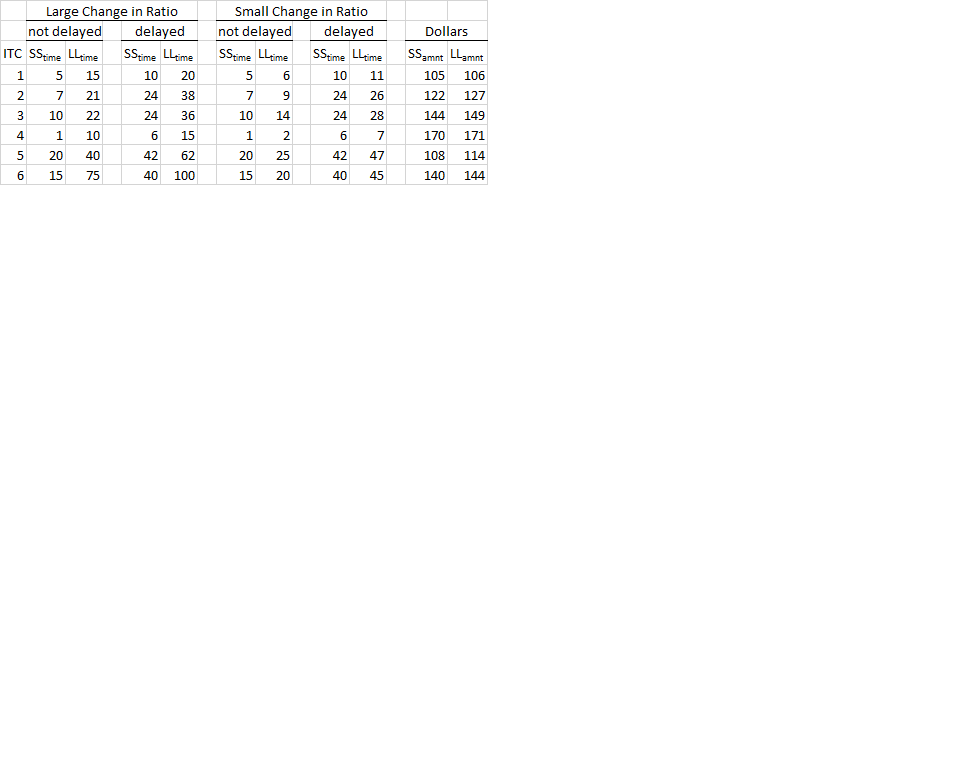

Participants then made unlikeness judgements between two times on a slider bar with a range of 0 - 100. Specifcally they were told: “For the first part of this study we will ask you how”unlike" you perceive two different points in time to be. You will be given a slider bar with: Not at all Unlike each other on the left and Completely Unlike each other on on the right"

Next within the ratio change condition the the delayed or not delayed block was shown first followed by the other block. This was done to minimize the chance that related choices were shown sequentially. Within each block choices were presented in a random order.

After completing 12 unlikeness judgments participants completed an unrelated task which will not be reported further. Next participants completed 12 intertemporal choice questions.

## 1.2 Results

### 1.2.1 Unlikeness Judgments

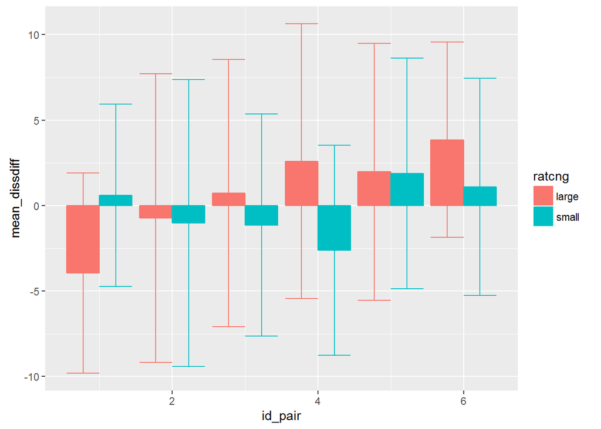

```
## Source: local data frame [6 x 9]
## Groups: id_pair [6]
##
##   id_pair   estimate  estimate1  estimate2   statistic   p.value parameter
##     (dbl)      (dbl)      (dbl)      (dbl)       (dbl)     (dbl)     (dbl)
## 1       1 -4.5464576 -3.9512195  0.5952381 -1.12470628 0.2640724  80.10523
## 2       2  0.2862950 -0.7380952 -1.0243902  0.04713366 0.9625227  80.99788
## 3       3  1.8604651  0.7209302 -1.1395349  0.35851823 0.7208844  81.33961
## 4       4  5.2099567  2.5909091 -2.6190476  1.00827337 0.3163821  79.50367
## 5       5  0.1017442  1.9767442  1.8750000  0.01974136 0.9842985  80.57884
## 6       6  2.7584204  3.8536585  1.0952381  0.63281251 0.5286550  80.25883
## Variables not shown: conf.low (dbl), conf.high (dbl)
```

### 1.2.2 ITC Choices

Below are the percentage of larger later choices for each of the ITC ids in both the delayed and not delayed conditions. The top panel is the large temporal ratio change condition and the bottom panel is the small temporal ratio change condition.

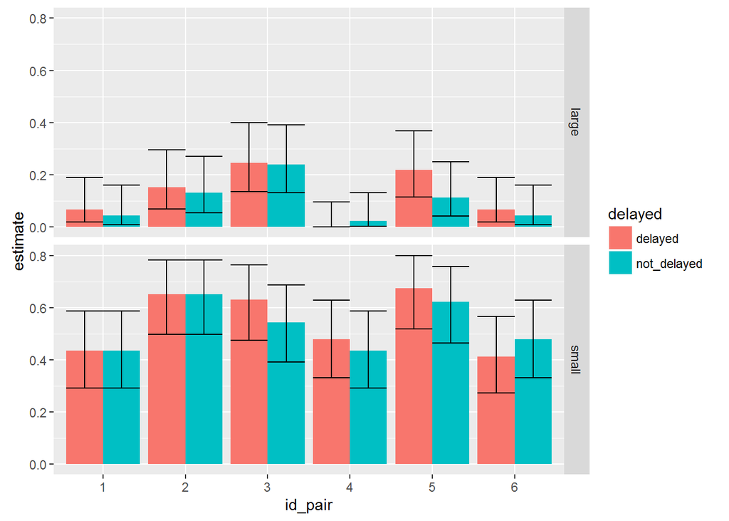

Next, for each intertemporal choice id, we ran a logistic regression predicting choice with 0 = Smaller Sooner and 1 = Larger Later. The indepent variables were whether or not the choice was delayed, the change in temporal ratio, and the interaction between the two. The figure below shows the regression coefficients along with the 95% CI.

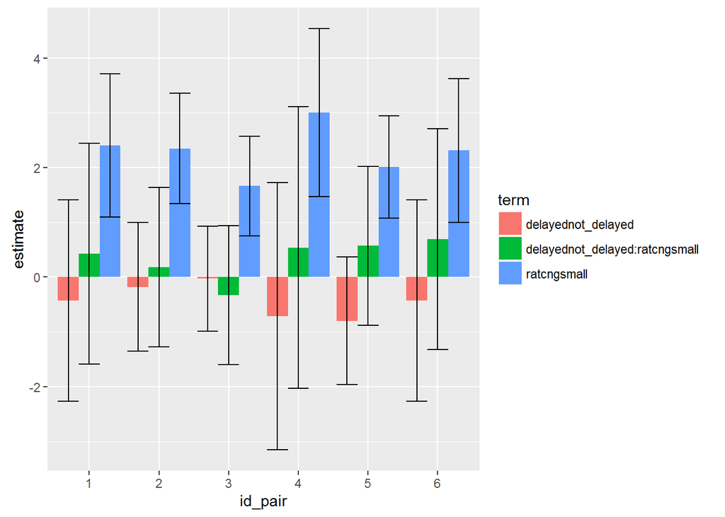

As expected, regardless of delay, people are significantly more likely to choose the larger later option when the ratio change is small. There is no effect of whether or not the the choice was delayed. Futher there was no interaction between delayed and the type of ratio change.

These results were confirmed by an omnibus logistic regression predicting choice with delay type, ratio change type, each unique intertemporal choice, and all possible interactions. As seen by the ANOVA below. There is a main effect of temporal ratio change and of each unique intertemporal choice, but no other effects approach significance.

```
## Analysis of Deviance Table (Type III tests)
##
## Response: value
##                                LR Chisq Df Pr(>Chisq)
## delayed                          0.2128  1   0.644543
## ratcng                          18.3048  1  1.882e-05 ***
## factor(id_pair)                 15.1894  5   0.009583 **
## delayed:ratcng                   0.1763  1   0.674602
## delayed:factor(id_pair)          1.2011  5   0.944769
## ratcng:factor(id_pair)           2.9247  5   0.711592
## delayed:ratcng:factor(id_pair)   1.2686  5   0.938133
## ---
## Signif. codes:  0 '***' 0.001 '**' 0.01 '*' 0.05 '.' 0.1 ' ' 1
```